# Assignment 1: Mixed Models

10466486

We are going to utilize mixed models built in R version 4.2.1 (2022-06-23) to answer two questions for two different data sets.

The first question was related to a one factor repeated measures design where participants were asked to respond to words appearing in different emotional contexts. We wanted to find out whether the contexts word appeared in influenced people’s speed of response.

The second question was related to a 2 by 2 repeated measures design where participants were first presented with a emotional story as a prime, before being asked to respond to faces with expressions congruent or incongruent to the prime. We wanted to find out how fast faces displaying emotions congruent or incongruent to the prime were attended to.

# Question 1: Touching Words

**What is the effect of words with different emotions on reaction time?**

A repeated measures design where 24 participants asked to respond to words appearing in neutral, negative, or positive emotional contexts. 24 word items were used and the reaction time measured in milliseconds was taken.

We first need to load all the package relevant for the first question.

```r
library(tidyverse)    # for various commands like read.csv and mutate to handle data

library(visdat)       # for missing value visualization

library(lme4)         # for building mixed models

library(emmeans)      # for Post Hoc tests

library(performance)  # to check for normality
```

## Reading and Tidying the Data

We will load in the data set and tidy the data into a format easier to work with. We will also see if there are any missing values that should be removed.

### Raw Data

Retrieve the raw data.

```r
raw_data_1 <- read.csv("assignment1_data1.csv") # store read data into variable
```

Outline of the data frame:

```
## 'data.frame':    574 obs. of  4 variables:
##  $ subj     : chr  "S1" "S1" "S1" "S1" ...
##  $ item     : chr  "I1" "I2" "I3" "I4" ...
##  $ DV       : int  867 1111 771 626 1333 846 547 1185 1254 926 ...
##  $ condition: chr  "Neutral" "Positive" "Negative" "Neutral" ...
```

First 6 rows:

```
##   subj item   DV condition
## 1   S1   I1  867   Neutral
## 2   S1   I2 1111  Positive
## 3   S1   I3  771  Negative
## 4   S1   I4  626   Neutral
## 5   S1   I5 1333  Positive
## 6   S1   I6  846  Negative
```

### Missing Values

There does not seem to be any missing values.

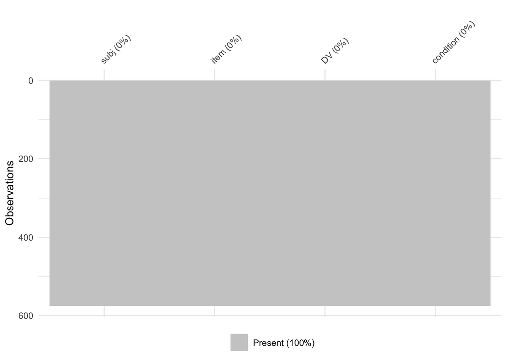

```r
vis_miss(raw_data_1) # creates visualization for any missing values
```

### Tidying data

Since there are no missing values to deal with the tidying process only requires minor changes. The format of the data is kept consistent with snake case. Variables such as condition, item, and subject were changed to factor type.

```r
tidied_data_1 <- raw_data_1 %>%
  rename(                                  # renames variables to complete meaningful words
    "subject" = "subj",
    "response_time" = "DV"                 # snake case per tidyverse format
         ) %>%
  mutate(                                  # change condition to a factor
    condition = factor(tolower(condition)) # change all to lower case
         )

tidied_data_1$subject <- as.factor(gsub("S", "", tidied_data_1$subject)) # append values in subject

# gsub parameters: (letter to replace, replace with nothing, look for letter in subject)
# as.factor: change to factor after gsub as it will override to change variable to character

tidied_data_1$item <- as.factor(gsub("I", "", tidied_data_1$item)) # appends values in item

# gsub: replaces letter 'I' with blank space
# as.factor: change item to factor
```

### Final Data

Outline of the data frame:

```
## 'data.frame':    574 obs. of  4 variables:
##  $ subject      : Factor w/ 24 levels "1","10","11",..: 1 1 1 1 1 1 1 1 1 1 ...
##  $ item         : Factor w/ 24 levels "1","10","11",..: 1 12 18 19 20 21 22 23 24 2 ...
##  $ response_time: int  867 1111 771 626 1333 846 547 1185 1254 926 ...
##  $ condition    : Factor w/ 3 levels "negative","neutral",..: 2 3 1 2 3 1 2 3 1 2 ...
```

First 6 rows:

```
##   subject item response_time condition
## 1       1    1           867   neutral
## 2       1    2          1111  positive
## 3       1    3           771  negative
## 4       1    4           626   neutral
## 5       1    5          1333  positive
## 6       1    6           846  negative
```

## Understanding the Data

We will now seek to understand the data a bit more by exploring descriptives and creating visualizations.

### Mean and Standard Deviation

From the output we can see that people are reacting to the negative condition the fastest, then the neutral, and finally the positive condition. Each condition differs by around 100ms from each other starting from the negative condition.

```r
tidied_data_1 %>%
  group_by(condition) %>% # groups same conditions together
  summarise(
    mean = mean(response_time), # calculate mean
    standard_deviation = sd(response_time) # calculate standard deviation
            ) %>%
  arrange(mean) # organize output by smallest to largest mean
```

```
## # A tibble: 3 × 3
##   condition  mean standard_deviation
##   <fct>     <dbl>              <dbl>
## 1 negative  1088.               565.
## 2 neutral   1185.               562.
## 3 positive  1257.               553.
```

From the violin distribution plot we can see observe it visually. As seen in the descriptives above each group differs from each other with the negative condition being the fastest and the positive condition being the slowest to respond to.

However, the standard deviations are large and overlapping for all conditions. We will need to run significance testing to see if this difference is meaningful.

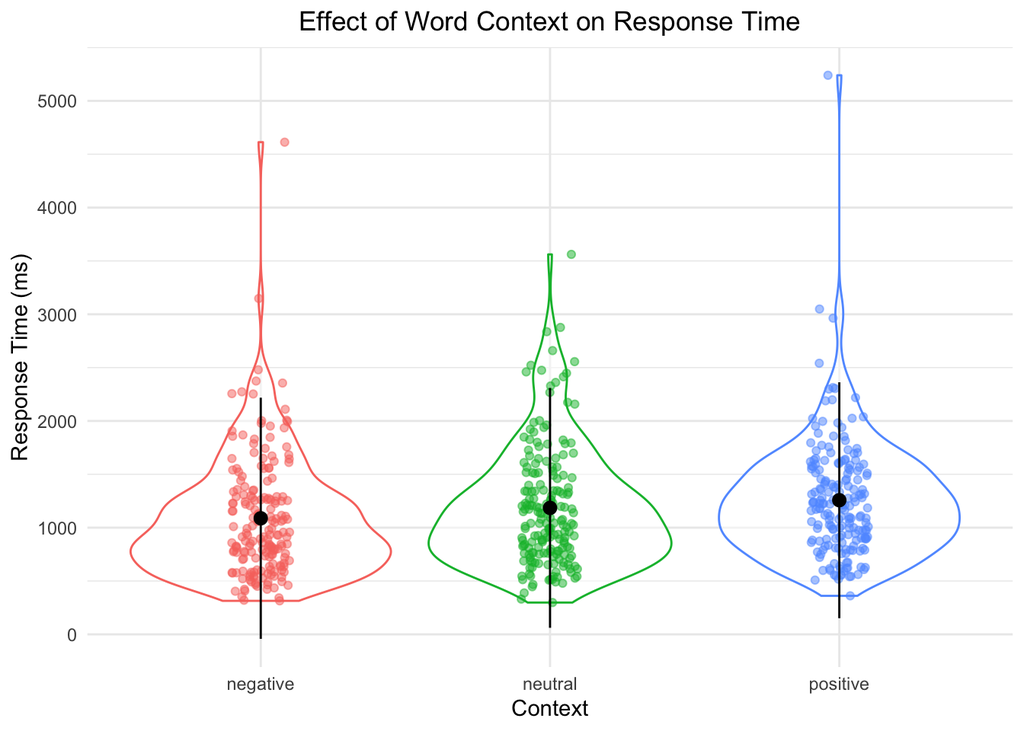

```r
set.seed(1) # keeps random elements of the plot consistent

tidied_data_1 %>%
  ggplot(aes(
             x = fct_reorder(condition, response_time), # set x; reorders by ascending response time
             y = response_time,                         # set y
             color = condition                          # color change by condition
             )
         ) +
  geom_violin(alpha = .5) +             # create violin; set transparency
  geom_jitter(alpha = .5, width = .1) + # create jitter; set transparency; set distance of points
  stat_summary(
               fun.data = "mean_sdl", # plot standard deviation
               geom = "pointrange",   # shape of standard deviation
               color = "black"        # set color
               ) +
  guides(color = "none") + # remove legends
  labs(
       x = "Context",                                    # label x
       y = "Response Time (ms)",                         # label y
       title = "Effect of Word Context on Response Time" # label title
       ) +
  theme_minimal() + # use preset theme
  theme(plot.title = element_text(hjust = .5) # center title
        )
```

### Range

Here we can use slightly different descriptive values to a picture the data. Based on the median we see the same pattern as the mean. People react to the negative condition fastest, then neutral, then react to positive condition the slowest.

```r
tidied_data_1 %>%
  group_by(condition) %>% # groups same conditions together
  summarise(
            min = min(response_time),                       # calculate minimum
            median = median(response_time),                 # calculate median
            max = max(response_time),                       # calculate maximum
            range = max(response_time) - min(response_time) # calculate range
            ) %>%
  arrange(median) # arrange by median from smallest to largest
```

```
## # A tibble: 3 × 5
##   condition   min median   max range
##   <fct>     <int>  <dbl> <int> <int>
## 1 negative    314    957  4613  4299
## 2 neutral     298   1065  3561  3263
## 3 positive    361   1208  5240  4879
```

A box plot shows these descriptives more clearly. Each conditions has a similar distribution as seen by the range and interquartile range.

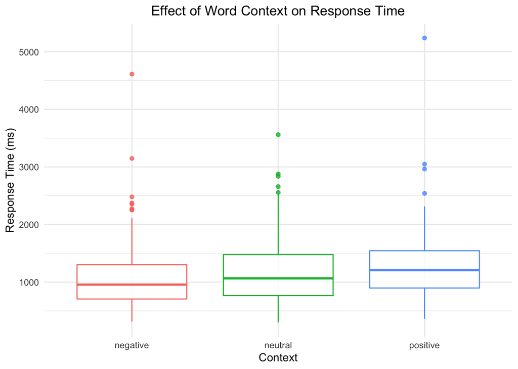

```r
tidied_data_1 %>%
  ggplot(aes(
             x = condition,     # set x
             y = response_time, # set y
             color = condition  # color by condition
             )
         ) +
  geom_boxplot(alpha = .8) + # create box plot; change transparency
  guides(color = "none") + # remove legend
  labs(
       x = "Context",                                    # label x
       y = "Response Time (ms)",                         # label y
       title = "Effect of Word Context on Response Time" # label title
       ) +
  theme_minimal() + # use preset theme
  theme(plot.title = element_text(hjust = .5) # center title
        )
```

## Building Models

In this section we will build models and check the model assumptions before conducting significance testing.

### Mixed Linear Model

We will build a mixed linear model by setting the dependent (response time) by independent (condition). Random effects are appointed to add more realism to the model. By including a variable as random effect indicate our recognition that the variable is representative of only a certain portion of a larger pool of data.

In our case, subject is chosen as we assume out subject is a sample potentially representative of a larger population. Item is chosen as we assume that the words use represent only a limited number of possible words.

```r
mixed_model_1 <- lmer(
                      response_time ~ condition + # set linear model response time by condition
                      (1 | subject) +             # subject as random effect
                      (1 | item),                 # items as random effect
                      data = tidied_data_1        # select data set
                      )
```

### Checking assumptions

We will proceed with our model as there doesn’t seem to be any major violations

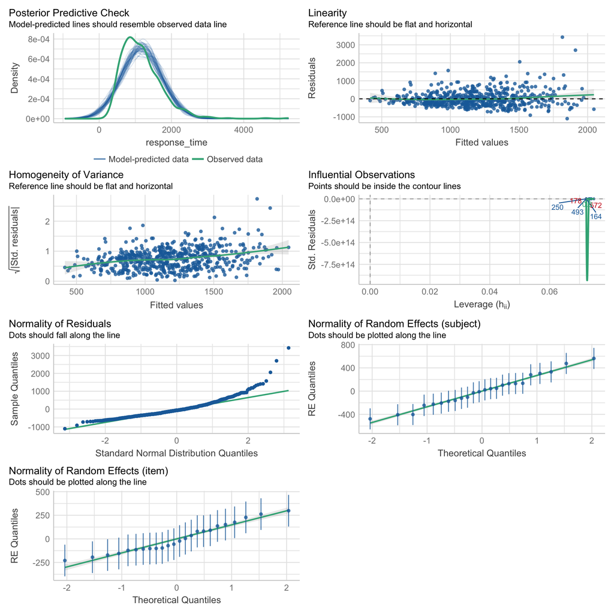

```r
check_model(mixed_model_1) # check assumptions
```

## T-test

### Results

[output not shown]

```r
emmeans(mixed_model_1, pairwise ~ condition, adjust = "bonferroni") # conduct t-test comparison

# scores adjusted by bonferroni correction
```

### Conclusion

**What is the effect of words with different emotions on reaction time?**

Positive words seem to take the longest for people to react to while negative words seem to take the shortest amount of time. They differ by a time of around 171 milliseconds.

# Question 2: Primed for Faces

**How does being primed for certain emotions affect people’s reaction time to different facial expressions?**

A 2 by 2 repeated measures design was conducted for 32 participants reacting to either angry or fearful facial expressions. A total of 32 different faces were shown. Beforehand, they were exposed to emotionally charged stories describing either a anger or fear inducing situation. Participant reaction times were measured in milliseconds.

We will load the necessary packages:

```r
library(tidyverse)    # for various commands like read.csv and mutate to handle data

library(visdat)       # for missing value visualization

library(lme4)         # for building mixed models

library(emmeans)      # for Post Hoc tests

library(performance)  # to check for normality

library(fitdistrplus) # to check for distribution fit
```

## Reading and Tidying the Data

We will load and tidy the data just as we did for the first question keeping the format consistent.

### Raw Data

Retrieve the raw data:

```r
raw_data_2 <- read.csv("assignment1_data2.csv")
```

Outline of the data frame:

```
## 'data.frame':    909 obs. of  5 variables:
##  $ Subject       : int  38 39 40 42 44 45 46 47 48 50 ...
##  $ Vignette      : int  10 10 9 10 9 10 10 9 10 10 ...
##  $ StoryEmotion  : chr  "Anger" "Anger" "Anger" "Anger" ...
##  $ FaceExpression: chr  "Anger" "Anger" "Anger" "Anger" ...
##  $ RT            : int  2896 2676 1199 2464 2010 2343 1386 2107 1103 3923 ...
```

First 6 rows:

```
##   Subject Vignette StoryEmotion FaceExpression   RT
## 1      38       10        Anger          Anger 2896
## 2      39       10        Anger          Anger 2676
## 3      40        9        Anger          Anger 1199
## 4      42       10        Anger          Anger 2464
## 5      44        9        Anger          Anger 2010
## 6      45       10        Anger          Anger 2343
```

### Missing Values

There does not seem to be any missing values.

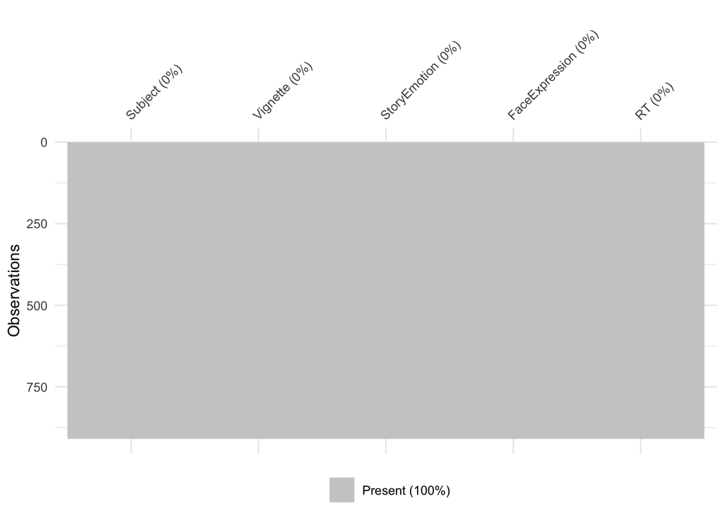

```r
vis_miss(raw_data_2) # creates visualization for any missing values
```

### Tidying Data

Here we change the variable names and their values into a consistent format. The variables are then changed into the correct type.

```r
tidied_data_2 <- raw_data_2 %>%
  rename(
         "subject" = "Subject", # rename each variable into meaningful words and snake case
         "vignette" = "Vignette",
         "story_emotion" = "StoryEmotion",
         "face_expression" = "FaceExpression",
         "reaction_time" = "RT"
         ) %>%
  mutate(
         story_emotion = factor(tolower(story_emotion)), # values to lower case, then to factors
         face_expression = factor(tolower(face_expression))
         )
```

### Final Data

Outline of the data frame:

```
## 'data.frame':    909 obs. of  5 variables:
##  $ subject        : int  38 39 40 42 44 45 46 47 48 50 ...
##  $ vignette       : int  10 10 9 10 9 10 10 9 10 10 ...
##  $ story_emotion  : Factor w/ 2 levels "anger","fear": 1 1 1 1 1 1 1 1 1 1 ...
##  $ face_expression: Factor w/ 2 levels "anger","fear": 1 1 1 1 1 1 1 1 1 1 ...
##  $ reaction_time  : int  2896 2676 1199 2464 2010 2343 1386 2107 1103 3923 ...
```

First 6 rows:

```
##   subject vignette story_emotion face_expression reaction_time
## 1      38       10         anger           anger          2896
## 2      39       10         anger           anger          2676
## 3      40        9         anger           anger          1199
## 4      42       10         anger           anger          2464
## 5      44        9         anger           anger          2010
## 6      45       10         anger           anger          2343
```

## Understanding the Data

From the mean results we can see that people react to congruent conditions faster for both angry and fearful primes than incongruent conditions. There is a greater difference in reaction time between incongruent and congruent trials for angry (785.437 milliseconds) than for fearful emotions (497.186 milliseconds).

```r
tidied_data_2 %>%
  group_by(story_emotion, face_expression) %>%     # groups same story and face condition together
  summarise(
            mean = mean(reaction_time),            # calculate mean
            standard_deviation = sd(reaction_time) # calculate standard deviation
            ) %>%
  arrange(.by_group = TRUE, -mean)                 # arrange mean largest to smallest mean

# arrange: by default it would arrange from smallest to largest value, "-" inverts the order
# arrange: by default arrange ignores groupings specified
```

```
## # A tibble: 4 × 4
## # Groups:   story_emotion [2]
##   story_emotion face_expression  mean standard_deviation
##   <fct>         <fct>           <dbl>              <dbl>
## 1 anger         fear            2634.              2025.
## 2 anger         anger           1848.              1079.
## 3 fear          anger           2525.              1867.
## 4 fear          fear            2028.              1163.
```

Further significance testing is needed to see whether a difference truly exists.

[figure not shown]

```r
prime_label <- c(
                 anger = "Angry Prime", # create character vectors to be used as lookup table
                 fear = "Fearful Prime"
                 )

set.seed(1) # allows random aspects fo "geom_jitter" to be reproducible

tidied_data_2 %>%
  ggplot(aes(
             x = story_emotion:face_expression,    # set x values by both conditions
             y = reaction_time,                    # set y values
             color = story_emotion:face_expression # separate groups by color
             )
         ) +
  geom_violin(alpha = .5) +               # create violin; change transparency
  geom_jitter(alpha = .5, width = .1) +   # create jitter; change transparency; change point distance
  stat_summary(
               fun.data = "mean_cl_boot", # 95% confidence level without assuming normality
               color = "black"            # change color to black
               ) +
  guides(color = "none") +                # removes legend
  labs(
       x = "Facial Expression",           # label x, y, and title
       y = "Reaction Time (ms)",
       title = "Reaction time of Congruency of Primed Emotion on Emotional Facial Expression"
       ) +
  facet_wrap(
             ~ story_emotion,                                 # wraps plot into separate panels
             scale = "free_x",                                # free scale for x in each panel
             labeller = labeller(story_emotion = prime_label) # changes label based on lookup table
             ) +
  scale_x_discrete(
                   labels = c(
                              "Congruent (Anger)", # change x tick labels
                              "Incongruent (Fear)",
                              "Incongruent (Anger)",
                              "Congruent (Fear)"
                              )
                   ) +
  theme(plot.title = element_text(hjust = .5))                     # center title
```

## Building Models

We are going to build linear mixed models and check for assumptions.

### Setting Contrasts

Changing the contrasts tells R to look at the data differently. Instead of looking at simple effects between each condition, we will look at main effects as with conditions compared to a grand mean (as will be shown by the intercept when looking at the result outputs).

```r
contrasts(tidied_data_2$story_emotion) <- matrix(c(.5, -.5)) # change contrasts for condition 1

contrasts(tidied_data_2$face_expression) <- matrix(c(.5, -.5)) # change contrasts for condition 2

# default uses matrix(c(0, 1) which interprets simple effects
```

### Mixed Linear Model

We will build a mixed linear model by setting the dependent (reaction time) by the 2 independent conditions (story emotion and face expression), and explore the interaction effects between the two. Random effects are assumed for subject and the items (vignettes).

```r
mixed_model_2 <- lmer(
                      reaction_time ~ story_emotion * face_expression + # set model by 2 conditions
                      (1 | subject) +                                   # subject as random effect
                      (1 | vignette),                                   # vignette as random effect
                      data = tidied_data_2                              # select data set
                      )
```

### Checking Assumptions

Visually inspecting the assumptions we can see that:

- Posterior Predictive Check: Has leptokurtic curve with high kurtosis
- Linearity: Violated
- Homogeneity: Violated
- Collinearity: Low and not violated
- Normality of Reaction Time: Points depart from normal towards the right
- Normality of Subject: Distribution of random effects for subject look departs from line
- Normality of Item: Distribution of random effects for item look normal as the points stick close to the line

We will move onto results keeping in mind the violation of normality.

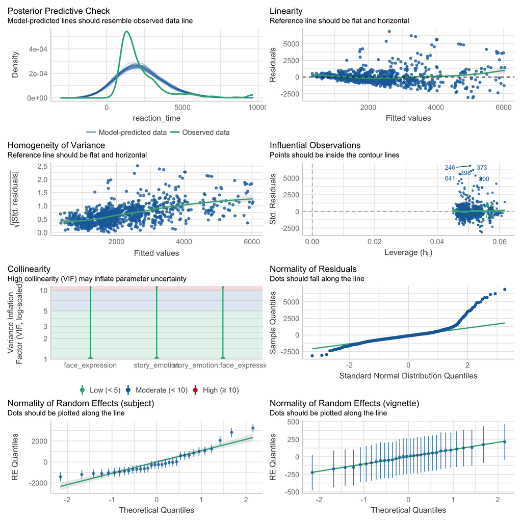

```r
check_model(mixed_model_2)
```

## T-test

### Results

From the summary statistics we can see there was only a significant interaction effect. *t*(869) = 9.25, *p* < .001,

```r
summary(mixed_model_2) # gives summary of results
```

```
## Linear mixed model fit by REML ['lmerMod']
## Formula: reaction_time ~ story_emotion * face_expression + (1 | subject) +
##     (1 | vignette)
##    Data: tidied_data_2
##
## REML criterion at convergence: 15371.1
##
## Scaled residuals:
##     Min      1Q  Median      3Q     Max
## -2.8765 -0.4938 -0.1083  0.2439  6.2997
##
## Random effects:
##  Groups   Name        Variance Std.Dev.
##  subject  (Intercept) 1361051  1166.6
##  vignette (Intercept)   27627   166.2
##  Residual             1185670  1088.9
## Number of obs: 909, groups:  subject, 32; vignette, 32
##
## Fixed effects:
##                                 Estimate Std. Error t value
## (Intercept)                      2289.70     211.50  10.826
## story_emotion1                    -37.27      93.60  -0.398
## face_expression1                 -121.60      73.29  -1.659
## story_emotion1:face_expression1 -1360.55     147.13  -9.248
##
## Correlation of Fixed Effects:
##             (Intr) stry_1 fc_xp1
## story_emtn1 -0.005
## fac_xprssn1  0.012 -0.065
## stry_mt1:_1 -0.015  0.053 -0.052
```

### Post Hoc T-tests

```r
emmeans(mixed_model_2, pairwise ~ story_emotion * face_expression, adjust = "bonferroni")

# conduct t-test comparisons
# bonferroni corrections made
```

```
## $emmeans
##  story_emotion face_expression emmean  SE   df lower.CL upper.CL
##  anger         anger             1870 222 38.8     1421     2319
##  fear          anger             2588 225 40.9     2133     3042
##  anger         fear              2672 222 39.1     2222     3122
##  fear          fear              2029 221 38.4     1581     2477
##
## Degrees-of-freedom method: kenward-roger
## Confidence level used: 0.95
##
## $contrasts
##  contrast                 estimate  SE    df t.ratio p.value
##  anger anger - fear anger   -717.5 122  83.3  -5.875  <.0001
##  anger anger - anger fear   -801.9 101 847.2  -7.928  <.0001
##  anger anger - fear fear    -158.9 115  67.1  -1.380  1.0000
##  fear anger - anger fear     -84.3 123  84.7  -0.688  1.0000
##  fear anger - fear fear      558.7 107 874.4   5.233  <.0001
##  anger fear - fear fear      643.0 116  69.2   5.542  <.0001
##
## Degrees-of-freedom method: kenward-roger
## P value adjustment: bonferroni method for 6 tests
```

### Conclusion

**How does being primed for certain emotions affect people’s reaction time to different facial expressions?**

People took longer to react to both fearful and angry facial expressions when the emotional prime was incongruent. People were faster to react when the emotional prime matched the facial expression presented.

### Distribution Fit

Based on the violation of normal we can test for the distribution fit. We see that the distribution is not a normal as assumed but closer to a beta distribution. This would influence the valididty of the conclusion

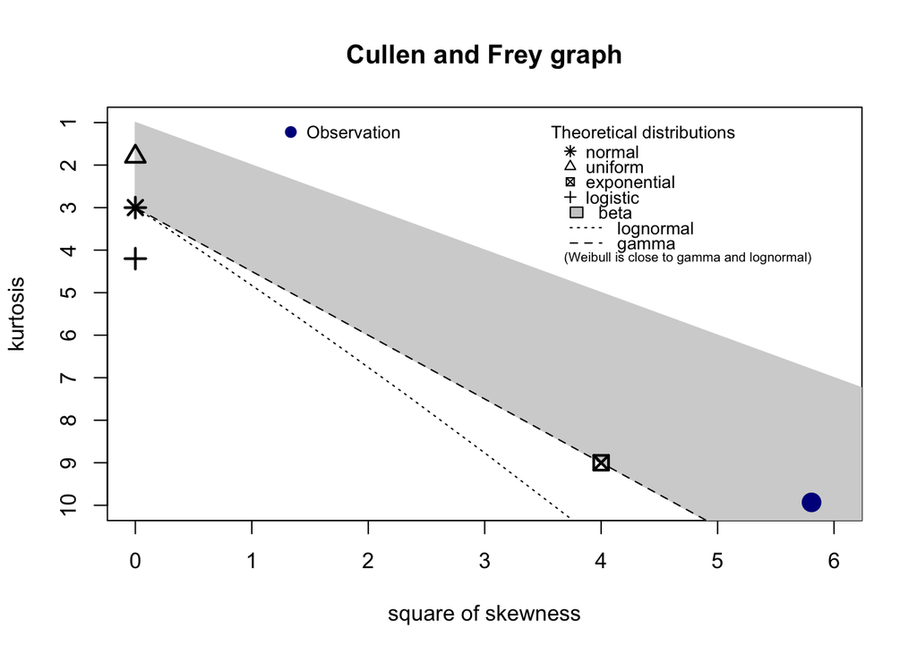

```
## summary statistics
## ------
## min:  363   max:  9652
## median:  1706
## mean:  2238.018
## estimated sd:  1595.012
## estimated skewness:  2.409722
## estimated kurtosis:  9.931861
```

```r
descdist(tidied_data_2$reaction_time) # test for distribution fit
```